#Statistical Inference Project

##Overview This project investigates the Exponential distribution in R and compares it with the Central Limit Theorem. The mean of the Exponential distribution is $\frac{1}{\lambda}$ and the standard deviation is also $\frac{1}{\lambda}$. A thousand simulations of the distribution of 40 exponentials would be investigated.

##Simulation The exponential distribution can be simulated in R with rexp(n, lambda), where lambda is the rate parameter and n is the number of observations. For the purpose of all the simulations in this project, value of lambda is set to 0.2. First we load the ggplot2 plotting library.

```r
library(ggplot2)
```

Then we will initialize the variables

```r
lamb <- 0.2
n <- 1000
sampsize <- 40
```

set seed for random variable

```r
set.seed(3)
```

create a matrix with 1000 rows and 40 column

```r
sampledMatrix <- matrix(rexp(sampsize*n , lamb) ,n, sampsize)
```

We find the means for each simulation

```r
means <- apply(sampledMatrix,1,mean)
```

calculate the simulated data

```r
sampleData <- data.frame(cbind(sampledMatrix,means))
```

plot the simulated means data

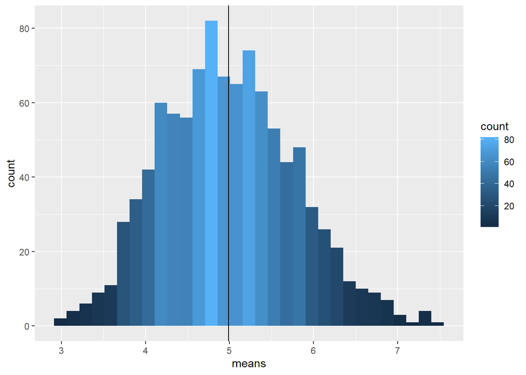

```r
ggplot(data = sampleData , aes(means)) + geom_histogram(aes(fill=..count..) , bins = round(sqrt(1000),1)) + geom_vline(xintercept = mean(means))
```

```r
actualMean <- mean(sampleData$means)
theoreticalMean <- 1/lamb
```

The Actual Mean is 4.9866197

The Theoretical Mean is 5

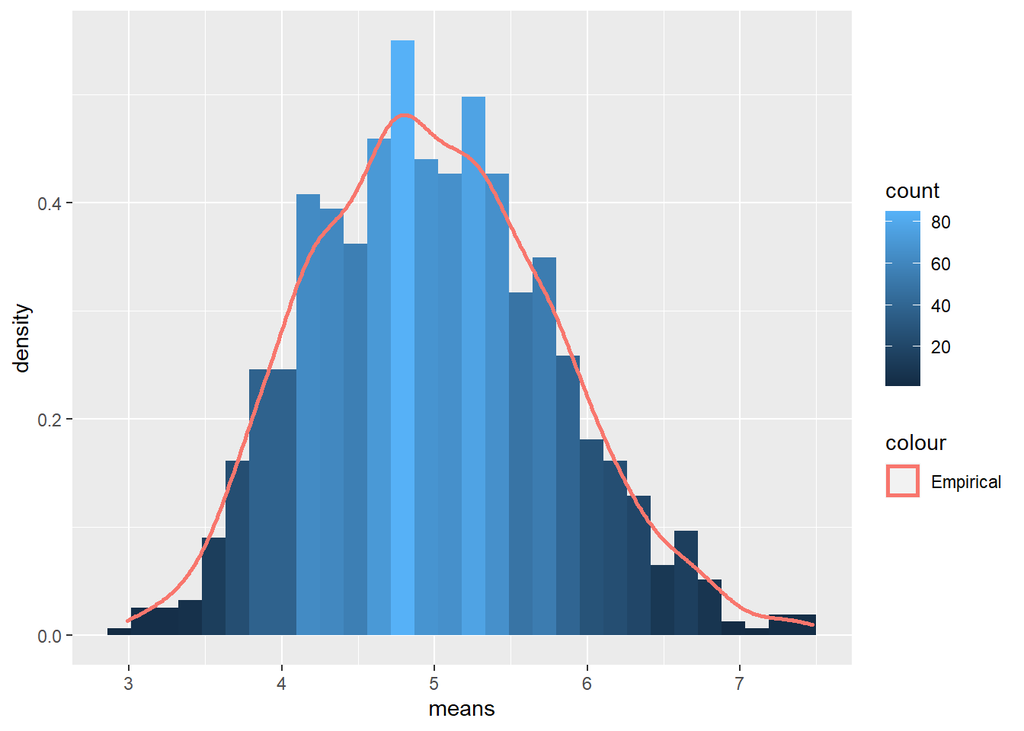

```r
ggplot(data = sampleData , aes(means)) + geom_histogram(aes(y = ..density.. ,fill=..count.. , bins = sqrt(length(means)))) + geom_density(aes(y=..density.., colour='Empirical'), size=1)
```

as we see it is nearly normal

```r
actualVariance <- var(means)
theoreticalVariance <-( (1/lamb)^2)/40
```

the actual Variance is 0.6257575

the theoretical Variance is 0.625

```r
actualConf <- actualMean +c(-1,1)*qnorm(0.95)*sqrt(actualVariance)
theoreticalConf <- theoreticalMean + c(-1,1)*qnorm(0.95)*sqrt(theoreticalVariance)
```